# 0212

```r
#####
# set up the environment
#####
# load packages
library(rethinking)
options(mc.cores = parallel::detectCores())
rstan_options(auto_write = TRUE)

# adjust the plot region for viewing on the projector in class
options(repr.plot.height=5)
```

```
rstan (Version 2.18.2, GitRev: 2e1f913d3ca3)
For execution on a local, multicore CPU with excess RAM we recommend calling
options(mc.cores = parallel::detectCores()).
To avoid recompilation of unchanged Stan programs, we recommend calling
rstan_options(auto_write = TRUE)
rethinking (Version 1.59)
```

## Predicting video game use

We will use another set of variables from the first wave of Add Health (collected in the United States from 1990 to 1991) to look at the time students spent playing video games.

Start by loading the data and looking at the first few rows to get a sense of it.

```r
d <- read.csv("https://mcmahanp.github.io/soci620/data/media.csv")
head(d)
```

| male | race_white | race_black | race_american_indian | race_asian_pacificislander | race_other | hispanic | grade | fam_income | fam_logincome | hours_tv | hours_videos | hours_games | hours_radio |
| --- | --- | --- | --- | --- | --- | --- | --- | --- | --- | --- | --- | --- | --- |
| FALSE | FALSE | TRUE | FALSE | FALSE | FALSE | FALSE | NA | 55000 | 10.915107 | 8 | 15 | 0 | 99 |
| FALSE | FALSE | TRUE | FALSE | FALSE | FALSE | FALSE | 11 | NA | NA | 33 | 4 | 0 | 2 |
| TRUE | TRUE | FALSE | FALSE | FALSE | FALSE | FALSE | 10 | 45000 | 10.714440 | 20 | 0 | 0 | 40 |
| TRUE | FALSE | TRUE | FALSE | FALSE | FALSE | FALSE | 12 | 9000 | 9.105091 | 24 | 6 | 7 | 7 |
| FALSE | FALSE | TRUE | FALSE | FALSE | FALSE | FALSE | 12 | 2000 | 7.601402 | 5 | 0 | 0 | 2 |
| TRUE | FALSE | TRUE | FALSE | FALSE | FALSE | FALSE | 7 | 70000 | 11.156265 | 14 | 0 | 0 | 14 |

In additionn to demographic data on gender, grade, race, ethnicity, and family income, this data lists the number of hours per week the students report spending consuming various media. We will be looking at `hours_games`, which codes students' responses to the question "How many hours a week do you play video or computer games?"

Start by looking at an overall summary variable and seeing how many values are missing.

```r
# how many missing (NA)?
sum(is.na(d$hours_games))
# proportion NA?
mean(is.na(d$hours_games))

# less than 0.2% missing
```

12

0.0018450184501845

```r
# for discrete data a table can give a quick summary of the values
tg <- table(d$hours_games)
as.matrix(tg)
# What proportion reported playing no games?
mean(d$hours_games==0,na.rm=TRUE)
```

| 0 | 3076 |
| --- | --- |
| 1 | 1013 |
| 2 | 727 |
| 3 | 362 |
| 4 | 199 |
| 5 | 263 |
| 6 | 103 |
| 7 | 116 |
| 8 | 51 |
| 9 | 18 |
| 10 | 174 |
| 11 | 7 |
| 12 | 46 |
| 13 | 1 |
| 14 | 45 |
| 15 | 66 |
| 16 | 6 |
| 17 | 1 |
| 18 | 9 |
| 19 | 2 |
| 20 | 60 |
| 21 | 15 |
| 23 | 1 |
| 24 | 13 |
| 25 | 15 |
| 26 | 1 |
| 28 | 6 |
| 30 | 24 |
| 32 | 1 |
| 34 | 1 |
| 35 | 16 |
| 36 | 1 |
| 37 | 1 |
| 38 | 1 |
| 40 | 12 |
| 42 | 6 |
| 45 | 2 |
| 48 | 2 |
| 49 | 5 |
| 50 | 9 |
| 60 | 4 |
| 64 | 1 |
| 70 | 2 |
| 78 | 1 |
| 80 | 1 |
| 84 | 1 |
| 96 | 1 |
| 99 | 4 |

0.473813924830561

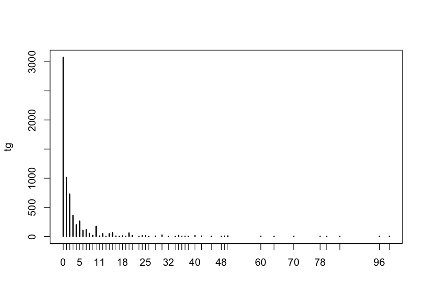

```r
# plot the table for a nice visualization
plot(tg)
```

So to summarize, about half of the students say they played no video games. A significant number also reported spending a suspisciously large amount of time playing, at least for the 1990s (8 hours per day and 16 hours per day on the weekend is 72 hours).